# LAB 5

## Introduction

In this project we are going to look at an inclusive search for the standard model Higgs boson in pp collisions at √ s = 13 TeV at the LHC using simulated data. The Higgs bosons are produced with large transverse momentum (pT) and decaying to a bottom quark-antiquark pair. The Higgs candidates could be reconstructed as large-radius jets using Calorimeters. Due to large QCD backgorund containmination, the direct 5-sigma observation of this Higgs channel is not accomplished yet. We are going to use a set of training datasets to optimize event selections in order to enhance the discovery sensitivity. The optimal event selections will be applied to a selected pseudo-experiment data.

## About the Experimental Data

The LHC produces around 1 billion events per second which is comparable to the speed of a CPU in a computer. This is great as it means that the computer can process the events - just barely - however the storage required to record an event is around 1 MB which, for 1 billion events, is not feasible. Instead, about 200 MB of data is written per second thus only about 100 to 200 of the 1 billion events are recorded. In order to determine which data to write and which data to throw away a triggering system is put in place - informed by the physical event that is trying to be observed. This system will result in recording events that satisfy a list of criteria. We could imagine one possible criteria would be for the mass of the particle observed to be around 125 Gev/c^2 if we were searching for the Higgs Boson.

### Downloading the Data

```python
%matplotlib inline
import numpy as np
import matplotlib
import matplotlib.pyplot as plt
import scipy
from scipy import stats
import h5py
import pickle
```

```python
infile_qcd = open("qcd_100000_pt_250_500.pkl",'rb')
qcd_data = pickle.load(infile_qcd)
infile_higgs = open("higgs_100000_pt_250_500.pkl", 'rb')
higgs_data = pickle.load(infile_higgs)
```

```python
qcd_data.keys()
```

```
Index(['pt', 'eta', 'phi', 'mass', 'ee2', 'ee3', 'd2', 'angularity', 't1',
       't2', 't3', 't21', 't32', 'KtDeltaR'],
      dtype='object')
```

```python
higgs_data.keys()
```

```
Index(['pt', 'eta', 'phi', 'mass', 'ee2', 'ee3', 'd2', 'angularity', 't1',
       't2', 't3', 't21', 't32', 'KtDeltaR'],
      dtype='object')
```

#### We can see that both the qcd dataset and higgs data set have the same features the description of the features are given below:-

pt : pt is the transverse momentum.

eta : $\eta$ is the pseudorapidity which is a geometric property. The pseudorapidity is used to describe the angle of the particle relative to the beam axis. This value ranges from $-\infty$ to $\infty$ as the polar angle $\theta$ goes from $0$ to $\pi$.

phi : $\phi$ is the azimuthal angle and it goes around the beam.

mass : is the mass of the particle produced via the collision.

ee2 : The 2-point energy correlation function. This energy correlation function is utilized for quark and gluon discrimination.

ee3 : The 3-point energy correlation function. This energy correlation function is utilized for boosted W / Z / Higgs Boson identification.

d2: $D_2$ is written in the following way where $E_{CFi}$ is the $i$-th energy correlation function: $D_2 = E_{CF3} * \big(\frac{E_{CF1}}{E_{CF2}}\big)^3$

angularity : Angularity is from the family of infrared-safe quantities that have characteristic distributions for two-body decays - the Higgs Boson.

t1 : t1 represents the 1-jettiness. This is the sum of the angular distance of each particle to the jet center.

t2 : t2 represents the 2-jettiness. This is the sum of the angular distance of each particle to that particle's respective jet center. With a jettiness of 2 we have two jet centers and our particles have been grouped into one or the other jet in order to minimize the value of t2.

t3 : t3 represents the 3-jettiness. This is the sum of the angular distance of each particle to that particle's respective jet center. With a jettiness of 3 we have three jet centers and our particles have been grouped into a jet in order to minimize the value of t3.

t21 : t21 is the ratio t2/t1 This captures how much of an improvement we made by grouping the particles with two jets instead of one.

t32 : t32 is the ratio t3/t2. This captures how much of an improvement we made by grouping the particles with three jets instead of two.

KtDeltaR: $k_t \Delta R$ is the $\Delta R$ of two subjects within a large-R jet. This is describing the algorithm that is being used to determine the jet centers for the particles - or the clustering algorithm.

## Data Observation

Below we are creating histograms for the for the event counts for the higgs(signal) and qcd(background) datasets for various features

```python
plt.rcParams["figure.figsize"] = (5,5)

def plot_feature(feature):


    # plot the background
    #plt.subplot(2, 1, 1)
    plt.hist(qcd_data[f'{feature}'], label = 'background')
    plt.title(f'{feature}' + '  Higgs Boson Signal /' + 'QCD Background')
    plt.xlabel(f'{feature}')
    plt.ylabel('Event counts')

    # plot the signal
    #plt.subplot(2, 1, 2)
    plt.hist(higgs_data[f'{feature}'], label = 'signal')
    #plt.title('Higgs Boson Signal')

    plt.xlabel(f' {feature}')
    plt.ylabel('Event counts')
    plt.legend()
    plt.show()
```

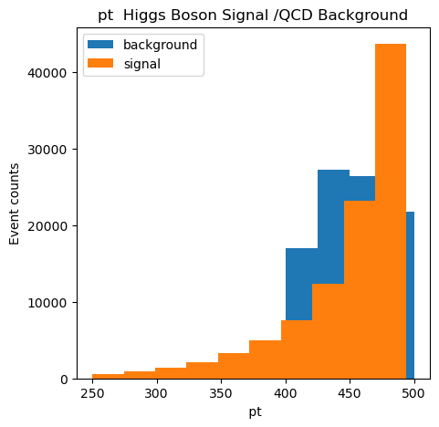

```python
plot_feature('pt')
```

The mean of the event counts for the 2 datasets are different and the range of the data for signal appears to be higher

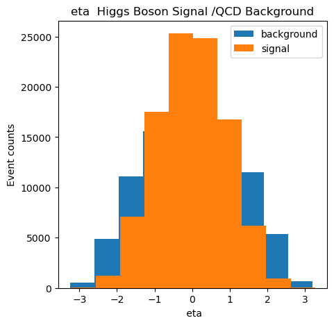

```python
plot_feature('eta')
```

The mean and range of the event counts for the 2 datasets appear to be same

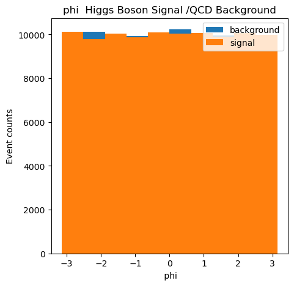

```python
plot_feature('phi')
```

The data for the 2 data sets seems to be non differentiable

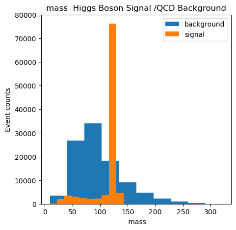

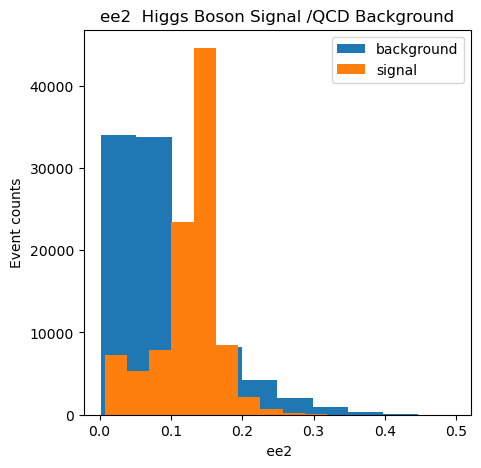

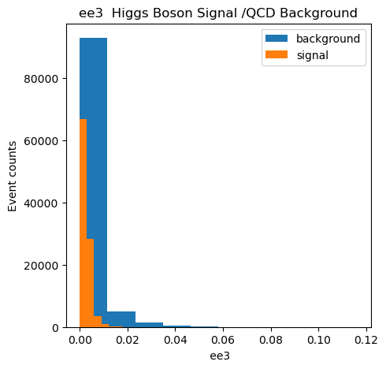

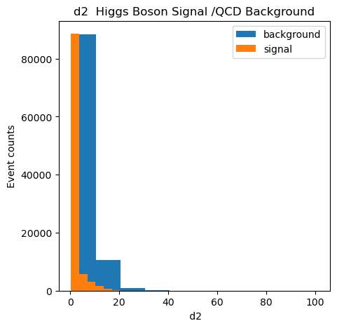

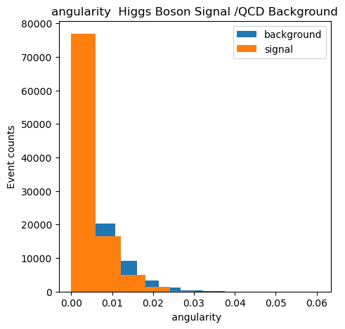

```python
plot_feature('mass')
plot_feature('ee2')
plot_feature('ee3')
plot_feature('d2')
plot_feature('angularity')
```

mass:The mean for the background and signal are different but closeby the range for the signal is lesser than the background

ee2: The mean for the background and signal are different the range for the background is slightly larger.

ee3:The mean for the background and signal are same the range for the background is larger.

d2:The mean for the background and signal are same the range for the background is larger.

angularity: The mean for the background and signal are same the range for the background is slightly larger.

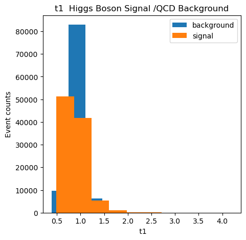

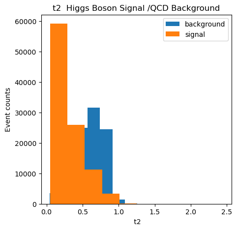

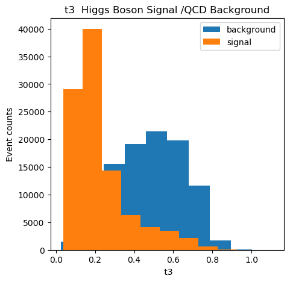

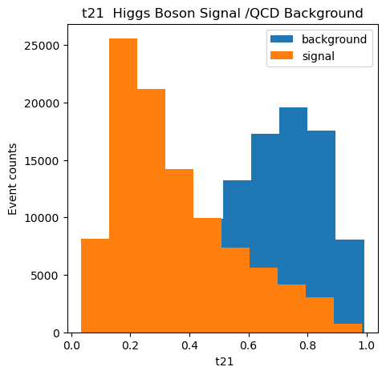

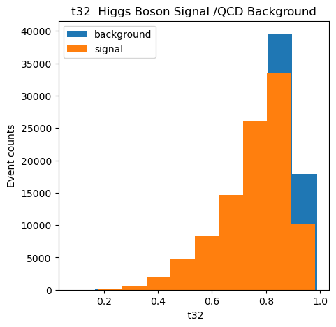

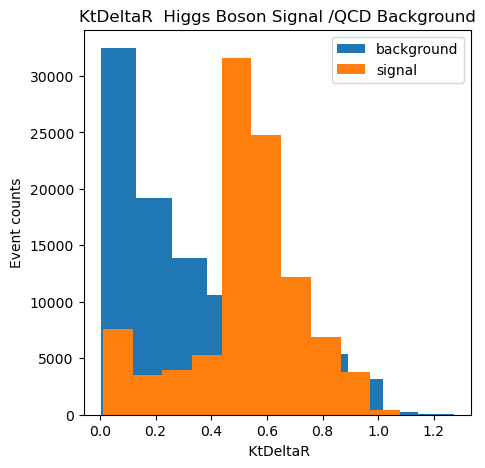

```python
plot_feature('t1')
plot_feature('t2')
plot_feature('t3')
plot_feature('t21')
plot_feature('t32')
plot_feature('KtDeltaR')
```

t1 : the mean is same the range of the background data is smaller

t2 : the mean is different the range of the background data is smaller

t3 : the mean is different the range of the background data is larger

t21 : the mean is different the range of the background data is slightly larger

t32 : the mean is same the range of the background data is slightly larger

KtDeltaR : the mean is different the range of the background data is larger

#### The following features provide discrimination power between signal and background:

pt, eta, ee2, ee3, d2, t2, t3, t21, KDeltaR, mass, angularity

#### The following features do not provide discrimination power between signal and background

phi,t32

#### The following features do provide discrimination power, however the discrimination is not large

t1

### Exploring the correlations in data

we know that $D_2 = E_{CF3} * \big(\frac{E_{CF1}}{E_{CF2}}\big)^3$ thus we can say that d2 is correlated to ee2, ee3 and ee1

we know that t21 = t2/t1, the plots of t21 and t2 are pretty similar in the sense that both the higg data and qcd data have diferent means and have the same range of data and t1 is similar but does not provide too much discrimination power

t32 = t3/t2,thus we know that t32 is correlated to t3 and t2. The plot for t32 does not provide much discrimination power however, the plot for t3 and t2 do, its difficult to find the correlation for these using the plots

### Expected Discovery Sensitivity

The number of data points for the qcd data set:

```python
len(qcd_data)
```

```
100000
```

The number of data points for the higgs data set:

```python
len(higgs_data)
```

```
100000
```

Expected yields of higgs events Nhiggs=100, Expected yields of background events Nqcd=20000

The background distribution is a poisson distribution with a mean of 20000 events to find the significance of our signal we need to find the significance of (Nhiggs + Nqcd) 20100 events.

```python
prob = stats.poisson.sf(20100, 20000)
sig = stats.norm.ppf(prob)
sig
```

```
-0.7112259282313185
```

Thus the significance of finding our signal is .7112259282313185

### Develop a plan to optimize the discovery sensitivity by applying selections to these features.

The significance is not high enough to confirm our signal, the significance required to confirm our signal is 5.

Thus, we need to develop a plan to optimize the discovery sensitivity by applying selections to these features.

Narrowing down the background based on ee3 will be good choice as the mean of the signal and the background for the histogram of this feature is the same and the width of the histogram for the signal is smaller than the background

We will remove all the data that has ee3 greater than 0.022

```python
cut_qcd = qcd_data[(qcd_data['ee3'] < .022)]
cut_higgs = higgs_data[(higgs_data['ee3'] < .022)]
```

The number of data points for the modified qcd dataset:

```python
len(cut_qcd)
```

```
97743
```

The number of data points for the higgs data set:

```python
len(cut_higgs)
```

```
99959
```

The ratio of expected yield to the number of data points for the qcd data is 20000/100000 = .2

The ratio of expected yield to the number of data points for the higgs data is 100/100000 = .001

thus the expected yield from the modified data is:

qcd_new_yield:

```python
.2 * 97743
```

```
19548.600000000002
```

higgs_new_yield:

```python
.001 * 99959
```

```
99.959
```

```python
19548.600000000002 + 99.959
```

```
19648.559
```

For our modified data the background distribution is a poisson distribution with a mean of 19548.600000000002 events to find the significance of our signal we need to find the significance of (higgs_new_yield + qcd_new_yield) 19648.559 events.

```python
prob = stats.poisson.sf(19648.559, 19548.600000000002 )
sig = stats.norm.ppf(prob)
sig
```

```
-0.7150926878208825
```

This slightly improves the significance but not by much as the number of background data points cut were not much let's furthur optimize by looking at the mass feature this would be a good choice as the range for our higgs data is much less than the qcd data thus we can remove a large amount of data points from our background.

```python
cut_qcd = cut_qcd[(cut_qcd['mass'] < 145)]
cut_higgs = cut_higgs[(cut_higgs['mass'] < 145)]
```

The number of data points for the qcd data set:

```python
len(cut_qcd)
```

```
86189
```

The number of data points for the higgs data set:

```python
len(cut_higgs)
```

```
99959
```

higgs_new_yield:

```python
.001 * 99959
```

```
99.959
```

qcd_new_yield:

```python
.2*86189
```

```
17237.8
```

```python
99.959 + 17237.8
```

```
17337.759
```

```python
prob = stats.poisson.sf(17337.759, 17237.8)
sig = stats.norm.ppf(prob)
sig
```

```
-0.7599093705061553
```

As we can see the significance again slightly improves but not enough clearly the amout of background data points cut off is still not enough let's give it another try for the t21 feature the number of data points greater than .7 is much larger for the qcd data set than the higgs dataset and for the KtDeltaR feature the number of data points less than .2 is much larger for the qcd data set than the higgs dataset thus, removing these data points should increase the significance of our detection

```python
cut_qcd = cut_qcd[(cut_qcd['t21'] < .7) & (cut_qcd['KtDeltaR'] > .2)]
cut_higgs = cut_higgs[(cut_higgs['t21'] < .7) & (cut_higgs['KtDeltaR'] > .2)]
```

The number of data points for the qcd data set:

```python
len(cut_qcd)
```

```
29970
```

The number of data points for the higgs data set:

```python
len(cut_higgs)
```

```
88020
```

higgs_new_yield:

```python
higgs_new_yield = .001 * len(cut_higgs)
higgs_new_yield
```

```
88.02
```

qcd_new_yield:

```python
qcd_new_yield = .2* len(cut_qcd)
qcd_new_yield
```

```
5994.0
```

```python
prob = stats.poisson.sf(qcd_new_yield + higgs_new_yield, qcd_new_yield)
sig = stats.norm.ppf(prob)
sig
```

```
-1.1424535203638255
```

We see that now the significance significantly improves however it is still bellow 5 (significance is enough to confirm our signal).Using the otherfeatures we can remove some data points from our dataset in a way that we are removing much more background data than our signal data similar to the process done above after a few iterations we should get a sigma vallue of 5.

```python
import os
os.system('jupyter nbconvert --to html lab5NB.ipynb')
```

```
0
```